# Exploratory Data Analysis - Chicago Taxi Trips

A in-depth exploratory data analysis for the Chicago taxi dataset. In order to efficiently perform exploratory data analysis, we used a subset containing 1% of the data for each of the provided training datasets so that our subset’s yearly proportions were the same as those of the full data’s. Hourly, daily, monthly and yearly trends were compared over repeated subsets to demonstrate that the trends in each subset were representative of the full data’s trends. It should be noted that the EDA plots and summary statistics examined in this section of the report are all run on the same 1% subset.

# Data

```r
library(data.table)
library(dplyr)
library(magrittr)
library(MASS)
library(ggplot2)
library(gridExtra)
library(kableExtra)
```

```r
taxi_2013 <- fread('subset_2013.csv')
taxi_2014 <- fread('subset_2014.csv')
taxi_2015 <- fread('subset_2015.csv')
taxi_2016 <- fread('subset_2016.csv')
taxi_2017 <- fread('subset_2017.csv')

taxi_2013[, 12 := NULL]
names(taxi_2014) <- names(taxi_2013)
names(taxi_2015) <- names(taxi_2013)
names(taxi_2016) <- names(taxi_2013)
names(taxi_2017) <- names(taxi_2013)

taxi_df <- data.table(rbindlist(list(taxi_2013, taxi_2014, taxi_2015, taxi_2016)),
                      Year = rep(c(2013, 2014, 2015, 2016), times = c(nrow(taxi_2013), nrow(taxi_2014), nrow(taxi_2015), nrow(taxi_2016))))

taxi_df <- na.omit(taxi_df)
taxi_2017 <- na.omit(taxi_2017)
```

Note that we have an extra column in the taxi_2013 data so we removed it.

## Previewing the data

| Trip ID | Taxi ID | Trip Start Timestamp | Trip End Timestamp | Trip Seconds | Trip Miles | Pickup Census Tract | Dropoff Census Tract | Pickup Community Area | Pickup O’Hare Community Area | Dropoff Community Area | Fare | Tips | Tolls | Extras | Trip Total | Payment Type | Company | Pickup Centroid Latitude | Pickup Centroid Longitude | Pickup Centroid Location | Dropoff Centroid Latitude | Dropoff Centroid Longitude | Dropoff Centroid Location | Year |
| --- | --- | --- | --- | --- | --- | --- | --- | --- | --- | --- | --- | --- | --- | --- | --- | --- | --- | --- | --- | --- | --- | --- | --- | --- |
| 8c98866acf97e2d43363c1e62d408dfb63368a8b | 6b50c5bb5761c3cb4853a8ca215dee42e63e922c7ebb0ce74cd52a2b3076c37ed38a45d19077a78a0bd19fe39c5e2efce4ed1ad13af2f2b67cbdb049839aae41 | 03/15/2013 5:15:00 PM | 03/15/2013 5:15:00 PM | 660 | 0.0 | 17031281900 | 17031081500 | 28 | 0 | 8 | $7.45 | $5.00 | $0.00 | $1.00 | $13.45 | Credit Card | Taxi Affiliation Services | 41.87926 | -87.64265 | POINT (-87.642648998 41.8792550844) | 41.89251 | -87.62621 | POINT (-87.6262149064 41.8925077809) | 2013 |
| 8c98ba8af921ff20f80b4a64ea5d4b130f5360c0 | ed7090d32800eec667900e884a935a298e55efaaaea9d66f2753858efee1178aeb3a874b413c4db7adf5e5c748efbe41682d4625acd9d540ca7e8983c8380b5b | 02/08/2013 7:45:00 PM | 02/08/2013 7:45:00 PM | 360 | 1.5 | 17031081800 | 17031839100 | 8 | 0 | 32 | $6.65 | $2.00 | $0.00 | $0.00 | $8.65 | Credit Card |  | 41.89322 | -87.63784 | POINT (-87.6378442095 41.8932163595) | 41.88099 | -87.63275 | POINT (-87.6327464887 41.8809944707) | 2013 |
| 8c98f469ae3f77d7ab46e41e3ae0491aba8d7ebc | bf426bcd9e203d196e477b945f87932c33c7f177d884ab76aad30e26723e7b5e1f62423c71acb8b299958af0de1c7fa195a45d71f2e67ec8dfc7a7662d97e66d | 05/04/2013 8:45:00 PM | 05/04/2013 8:45:00 PM | 480 | 0.0 | 17031831000 | 17031062700 | 22 | 0 | 6 | $7.25 | $0.00 | $0.00 | $1.00 | $8.25 | Cash | Taxi Affiliation Services | 41.91601 | -87.67510 | POINT (-87.6750951155 41.9160052737) | 41.93609 | -87.66611 | POINT (-87.6661106945 41.9360865352) | 2013 |
| 8c9a454a2e2fe9f04471f266c71d4a19ec413f29 | c0250f358cae01c5319aeb7b39827e53f9a2259eb32e4c2fba048fd9e7d0a69ebc41c807016fb9f2d815b8a248163904bdbad4ddbe6196d7001757d5ccd40133 | 09/11/2013 12:45:00 PM | 09/11/2013 1:00:00 PM | 420 | 0.0 | 17031320100 | 17031081800 | 32 | 0 | 8 | $6.25 | $2.00 | $0.00 | $0.00 | $8.25 | Credit Card | Blue Ribbon Taxi Association Inc. | 41.88499 | -87.62099 | POINT (-87.6209929134 41.8849871918) | 41.89322 | -87.63784 | POINT (-87.6378442095 41.8932163595) | 2013 |
| 8c9a71715c08f9be6b70f6ccdbdb55e8b64c725d | 8b07f9156e568a37d362463c84dbd1118b4eeb753bae502fded3dd7ba0040f5476ebbabb0428fc752b6b1e3de90c50ae9f33c396493a873a33c9663c51fe2508 | 12/14/2013 9:00:00 PM | 12/14/2013 9:30:00 PM | 1620 | 0.0 | 17031241400 | 17031070400 | 24 | 0 | 7 | $16.25 | $3.45 | $0.00 | $1.00 | $20.70 | Credit Card | Choice Taxi Association | 41.90603 | -87.67531 | POINT (-87.6753116216 41.906025969) | 41.92897 | -87.65616 | POINT (-87.6561568309 41.9289672664) | 2013 |
| 8c9b5278159c4c8a3fba3292b4bb326fc927fed1 | d5ca4708ec7536df92968ff54683f27934c4c48beb482f831315a48b6e116dac3b944c0765bbe76b073f6cd5696a70e5b500d200db836c698e82855bddfae88e | 02/01/2013 10:45:00 AM | 02/01/2013 11:00:00 AM | 300 | 0.8 | 17031081403 | 17031081201 | 8 | 0 | 8 | $5.25 | $1.00 | $0.00 | $0.00 | $6.25 | Credit Card | Dispatch Taxi Affiliation | 41.89092 | -87.61887 | POINT (-87.6188683546 41.8909220259) | 41.89916 | -87.62621 | POINT (-87.6262105324 41.8991556134) | 2013 |

# Analysis of predictors over time

Before we begin let’s create some datetime variables for our time.

```r
date_time_2013 <- strptime(taxi_2013$`Trip Start Timestamp`, format = '%m/%d/%Y %I:%M:%S %p')
date_time_2014 <- strptime(taxi_2014$`Trip Start Timestamp`, format = '%m/%d/%Y %I:%M:%S %p')
date_time_2015 <- strptime(taxi_2015$`Trip Start Timestamp`, format = '%m/%d/%Y %I:%M:%S %p')
date_time_2016 <- strptime(taxi_2016$`Trip Start Timestamp`, format = '%m/%d/%Y %I:%M:%S %p')
date_time <- strptime(taxi_df$`Trip Start Timestamp`, format = '%m/%d/%Y %I:%M:%S %p')
date_time2 <- strptime(taxi_df$`Trip End Timestamp`, format = '%m/%d/%Y %I:%M:%S %p')

# Add month column
taxi_df[, Month := as.numeric(strftime(date_time, '%m'))]
```

## By Month

Let’s begin by doing a breakdown by the month of year.

### Trip Duration

The first variable we want to examine is trip duration and how it varies from month to month.

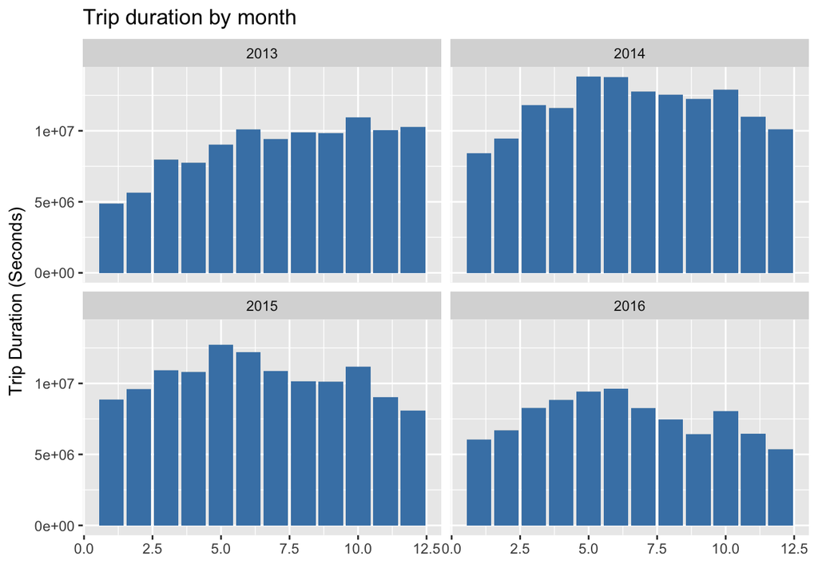

```r
g1 <- taxi_df[, .(TripDuration = `Trip Seconds`, Month), by = Year] %>%
  ggplot(aes(Month, TripDuration)) +
  geom_bar(stat = 'identity', fill = 'steelblue') +
  facet_wrap(~ as.factor(Year)) +
  labs(x = '', y = 'Trip Duration (Seconds)', title = 'Trip duration by month')
g1
```

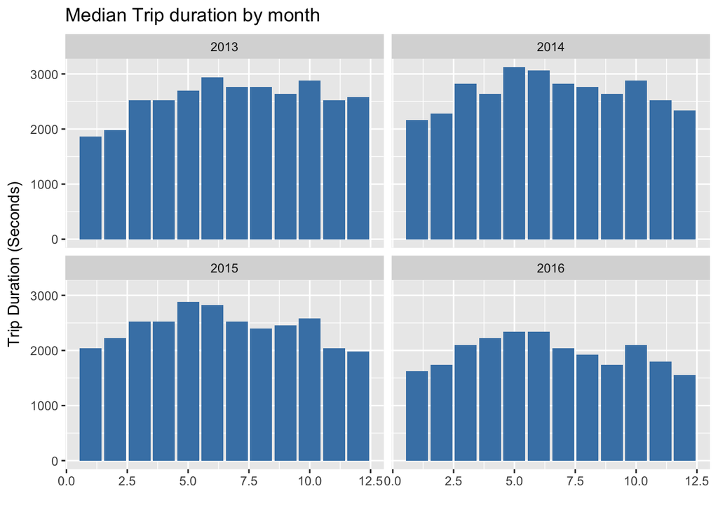

```r
g2 <- taxi_df[, .(TotalTrip = sum(`Trip Seconds`)), by = list(`Taxi ID`, Month, Year)][, .(Median = median(TotalTrip)), by = list(Month, Year)][order(Year, Month), ] %>%
  ggplot(aes(Month, Median)) +
  geom_bar(stat = 'identity', fill = 'steelblue') +
  facet_wrap(~ as.factor(Year)) +
  labs(x = '', y = 'Trip Duration (Seconds)', title = 'Median Trip duration by month')
g2
```

Looking at the median trip durations, we still see that the peaks are generally in May, June, and October and that the low points are in January. The difference is not as big though.

### Trip Count

Now let’s investigate the number of trips that have been taken each month.

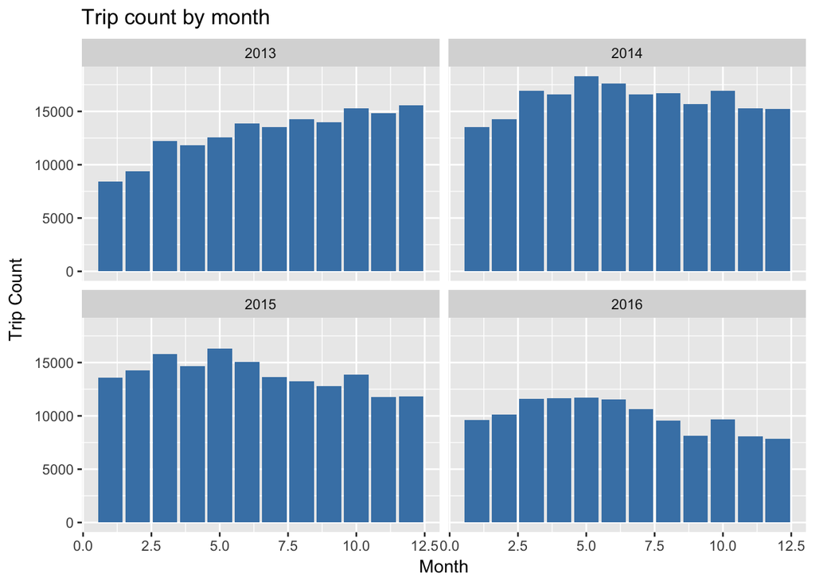

```r
g3 <- taxi_df[, .(Month), by = Year][, .(TripCount = .N), by = c('Year', 'Month')] %>%
  ggplot(aes(Month, TripCount)) +
  geom_bar(stat = 'identity', fill = 'steelblue') +
  facet_wrap(~ as.factor(Year)) +
  labs(x = 'Month', y = 'Trip Count', title = 'Trip count by month')
g3
```

### Trip Distance

The last variable we want to look into is the trip distance for each month.

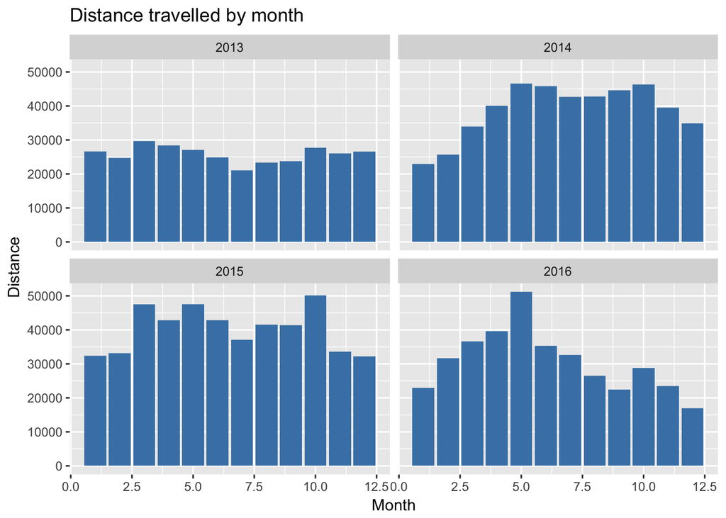

```r
g4 <- taxi_df[, .(TripDistance = `Trip Miles`, Month), by = Year] %>%
  ggplot(aes(Month, TripDistance)) +
  geom_bar(stat = 'identity', fill = 'steelblue') +
  facet_wrap(~ as.factor(Year)) +
  labs(x = 'Month', y = 'Distance', title = 'Distance travelled by month')
g4
```

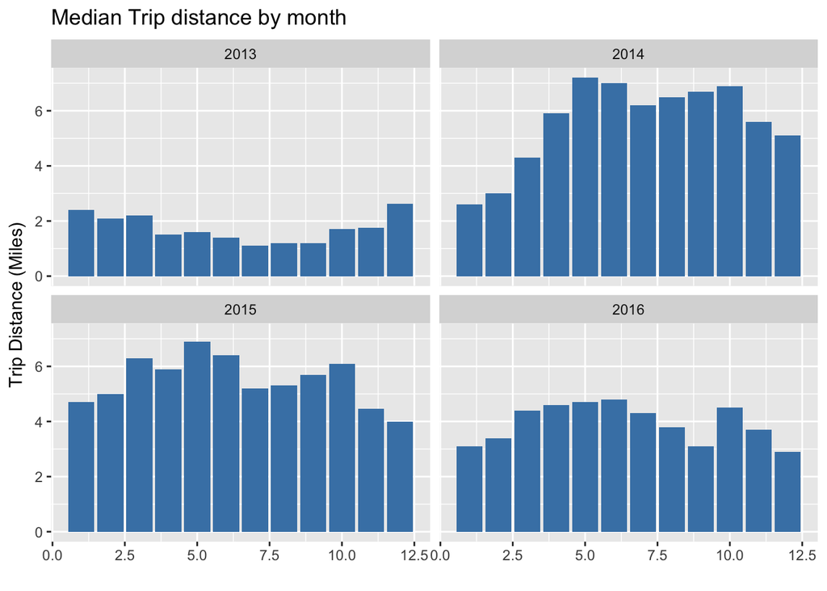

```r
g5 <- taxi_df[, .(TotalTrip = sum(`Trip Miles`)), by = list(`Taxi ID`, Month, Year)][, .(Median = median(TotalTrip)), by = list(Month, Year)][order(Year, Month), ] %>%
  ggplot(aes(Month, Median)) +
  geom_bar(stat = 'identity', fill = 'steelblue') +
  facet_wrap(~ as.factor(Year)) +
  labs(x = '', y = 'Trip Distance (Miles)', title = 'Median Trip distance by month')
g5
```

The median trip distance shows a large spike from 2013-2014 and then a large decrease from 2015-2016.

## By Day of the week

We now do a closer inspection on the same variables, but now we look at the trends by the day of the week.

### Trip Duration

We will start with trip duration again.

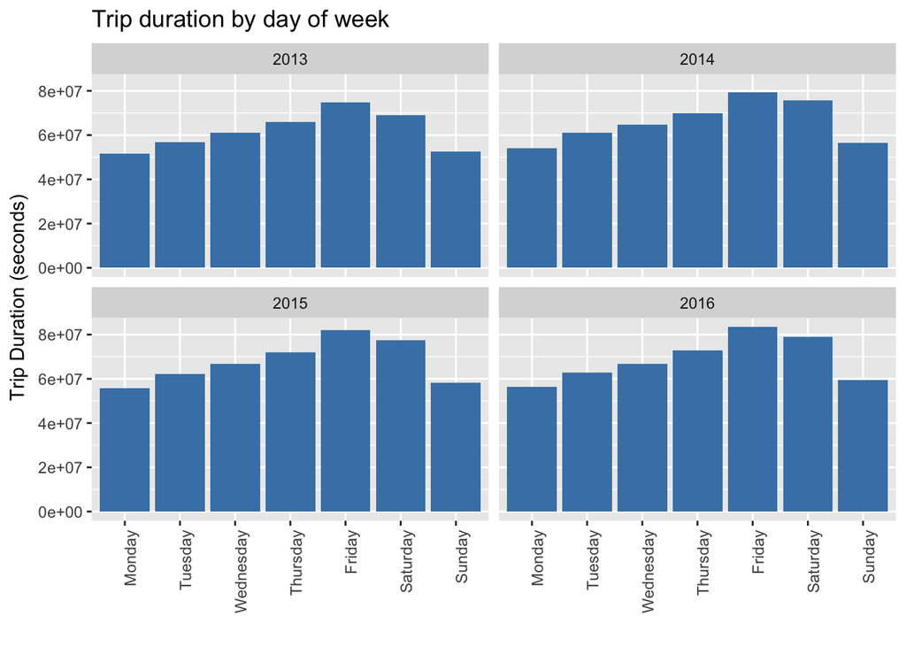

```r
g6 <- taxi_df[, .(TripDuration = `Trip Seconds`,
                   Day = factor(weekdays(as.Date(date_time)), levels = c('Monday', 'Tuesday', 'Wednesday', 'Thursday', 'Friday', 'Saturday', 'Sunday'))), by = Year] %>%
  ggplot(aes(Day, TripDuration)) +
  geom_bar(stat = 'identity', fill = 'steelblue') +
  facet_wrap(~ as.factor(Year)) +
  labs(x = '', y = 'Trip Duration (seconds)', title = 'Trip duration by day of week') +
  theme(axis.text.x = element_text(angle = 90, hjust = 1))
g6
```

We see that trips duration is the most on Fridays and Saturdays for all years. Like our previous analysis with trip duration by month, we want to also look at the median trip duration to assess individual rides.

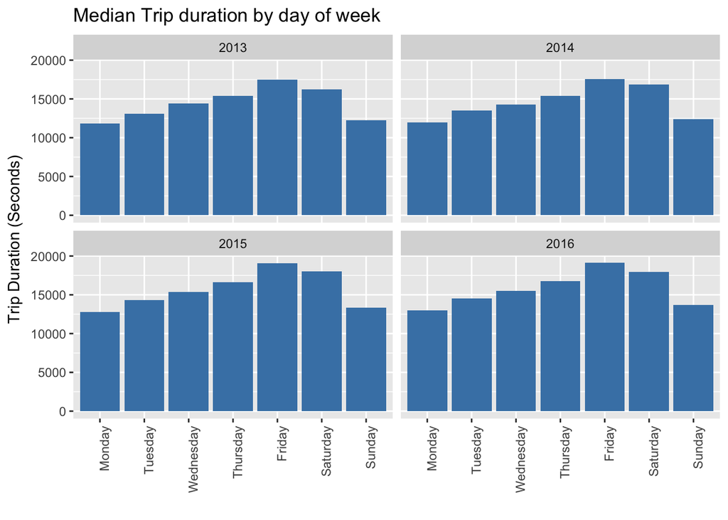

```r
g7 <- taxi_df[, .(TaxiID = `Taxi ID`,
                  TripDuration = `Trip Seconds`,
                  Day = factor(weekdays(as.Date(date_time)), levels = c('Monday', 'Tuesday', 'Wednesday', 'Thursday', 'Friday', 'Saturday', 'Sunday'))), by = Year][, .(TotalTrip = sum(TripDuration)), by = list(TaxiID, Day, Year)][, .(Median = median(TotalTrip)), by = list(Day, Year)] %>%
  ggplot(aes(Day, Median)) +
  geom_bar(stat = 'identity', fill = 'steelblue') +
  facet_wrap(~ as.factor(Year)) +
  labs(x = '', y = 'Trip Duration (Seconds)', title = 'Median Trip duration by day of week ') +
  theme(axis.text.x = element_text(angle = 90, hjust = 1))
g7
```

The median trip duration seems to follow the same trend as total trip duration, having the high points on Fridays and Saturdays, so we can expect individual taxi trip durations to behave in this pattern. It makes sense that Friday and Saturday see the longest trip durations as that is when people are more likely to go out and grab drinks or travel to the to and from the airport.

### Trip Count

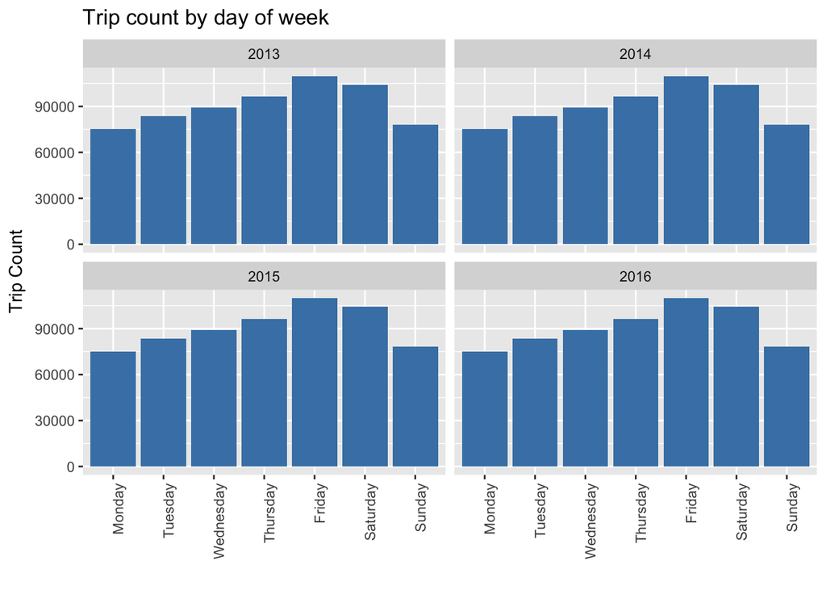

```r
g8 <- taxi_df[, .(Day = factor(weekdays(as.Date(date_time)), levels = c('Monday', 'Tuesday', 'Wednesday', 'Thursday', 'Friday', 'Saturday', 'Sunday'))), by = Year][, .(TripCount = .N), by = c('Year', 'Day')] %>%
  ggplot(aes(Day, TripCount)) +
  geom_bar(stat = 'identity', fill = 'steelblue') +
  facet_wrap(~ as.factor(Year)) +
  labs(x = '', y = 'Trip Count', title = 'Trip count by day of week') +
  theme(axis.text.x = element_text(angle = 90, hjust = 1))
g8
```

As expected, the trip count follows the same trend as the total trip duration and also the median trip duration with the peaks being on Friday and Saturdays.

### Trip Distance

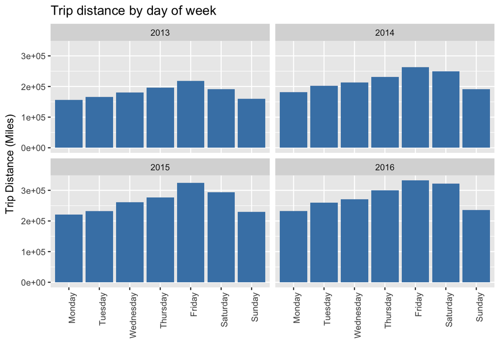

```r
g9 <- taxi_df[, .(TripDistance = `Trip Miles`,
                   Day = factor(weekdays(as.Date(date_time)), levels = c('Monday', 'Tuesday', 'Wednesday', 'Thursday', 'Friday', 'Saturday', 'Sunday'))), by = Year] %>%
  ggplot(aes(Day, TripDistance)) +
  geom_bar(stat = 'identity', fill = 'steelblue') +
  facet_wrap(~ as.factor(Year)) +
  labs(x = '', y = 'Trip Distance (Miles)', title = 'Trip distance by day of week') +
  theme(axis.text.x = element_text(angle = 90, hjust = 1))
g9
```

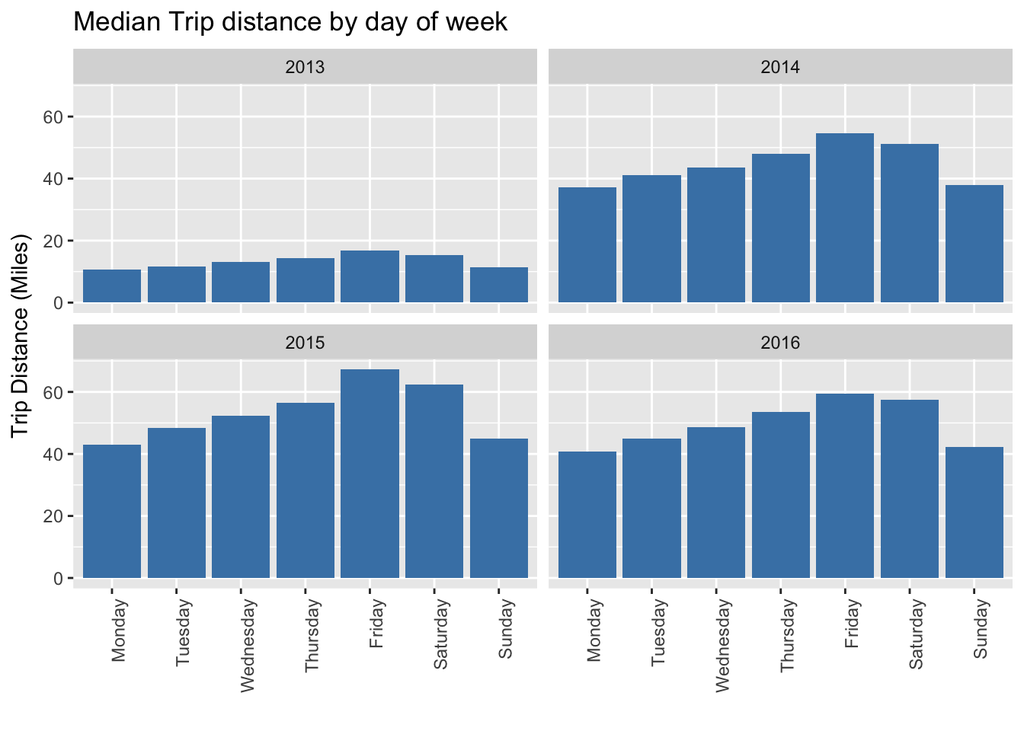

```r
g10 <- taxi_df[, .(TaxiID = `Taxi ID`,
                  TripDistance = `Trip Miles`,
                  Day = factor(weekdays(as.Date(date_time)), levels = c('Monday', 'Tuesday', 'Wednesday', 'Thursday', 'Friday', 'Saturday', 'Sunday'))), by = Year][, .(TotalTrip = sum(TripDistance)), by = list(TaxiID, Day, Year)][, .(Median = median(TotalTrip)), by = list(Day, Year)] %>%
  ggplot(aes(Day, Median)) +
  geom_bar(stat = 'identity', fill = 'steelblue') +
  facet_wrap(~ as.factor(Year)) +
  labs(x = '', y = 'Trip Distance (Miles)', title = 'Median Trip distance by day of week') +
  theme(axis.text.x = element_text(angle = 90, hjust = 1))
g10
```

Not much appears to change in this plot except that the 2013 median trip distance is very low.

## By Hour of day

Lastly we want to break it down even further and analyze trends by the hour of any day.

### Trip Duration

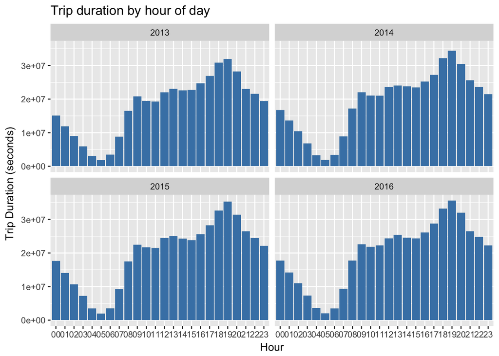

```r
g11 <- taxi_df[, .(TripDuration = `Trip Seconds`, Hour = strftime(date_time, '%H')), by = Year] %>%
  ggplot(aes(Hour, TripDuration)) +
  geom_bar(stat = 'identity', fill = 'steelblue') +
  facet_wrap(~ as.factor(Year)) +
  labs(x = 'Hour', y = 'Trip Duration (seconds)', title = 'Trip duration by hour of day')
g11
```

[figure not shown]

```r
g12 <- taxi_df[, .(TripDuration = `Trip Seconds`,
                   Hour = strftime(date_time, '%H')), by = Year] %>%
  ggplot(aes(Hour, TripDuration)) +
  geom_bar(stat = 'identity', fill = 'steelblue') +
  facet_wrap(~ as.factor(Year)) +
  labs(x = '', y = 'Trip Duration (seconds)', title = 'Median Trip duration by hour of day')
g12
```

### Trip Count

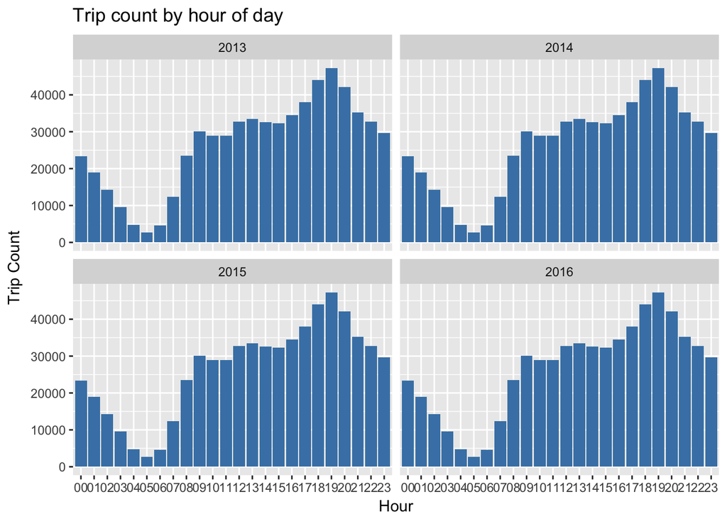

```r
g13 <- taxi_df[, .(Hour = strftime(date_time, '%H')), by = Year][, .(TripCount = .N), by = c('Year', 'Hour')] %>%
  ggplot(aes(Hour, TripCount)) +
  geom_bar(stat = 'identity', fill = 'steelblue') +
  facet_wrap(~ as.factor(Year)) +
  labs(x = 'Hour', y = 'Trip Count', title = 'Trip count by hour of day')
g13
```

### Trip Distance

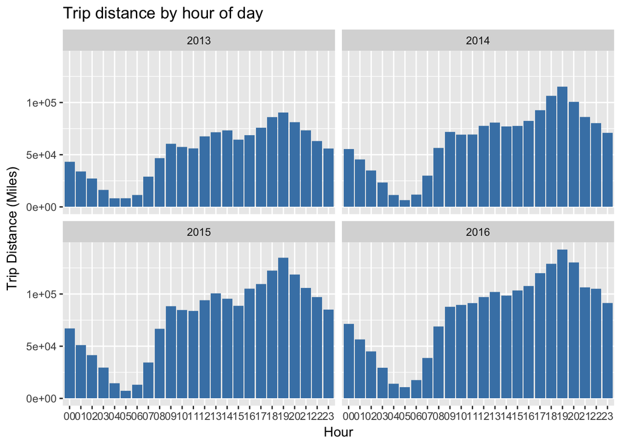

```r
g14 <- taxi_df[, .(TripDistance = `Trip Miles`, Hour = strftime(date_time, '%H')), by = Year] %>%
  ggplot(aes(Hour, TripDistance)) +
  geom_bar(stat = 'identity', fill = 'steelblue') +
  facet_wrap(~ as.factor(Year)) +
  labs(x = 'Hour', y = 'Trip Distance (Miles)', title = 'Trip distance by hour of day')
g14
```

And the median trip distance.

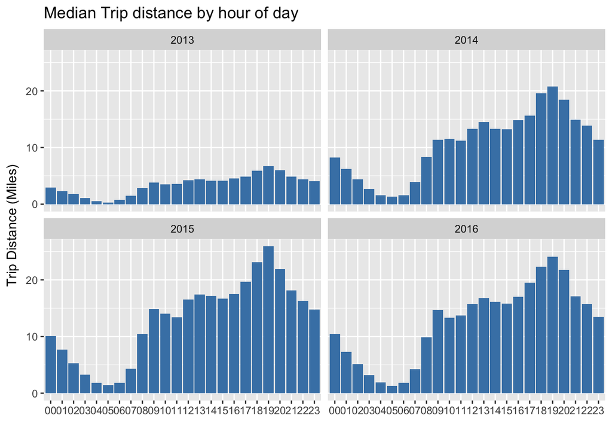

```r
g15 <- taxi_df[, .(TaxiID = `Taxi ID`,
                  TripDistance = `Trip Miles`,
                  Hour = strftime(date_time, '%H')), by = Year][, .(TotalTrip = sum(TripDistance)), by = list(TaxiID, Hour, Year)][, .(Median = median(TotalTrip)), by = list(Hour, Year)] %>%
  ggplot(aes(Hour, Median)) +
  geom_bar(stat = 'identity', fill = 'steelblue') +
  facet_wrap(~ as.factor(Year)) +
  labs(x = '', y = 'Trip Distance (Miles)', title = 'Median Trip distance by hour of day')
g15
```